# Practical Machine Learning / Prediction Assignment

## Synopsis

Using devices such as Jawbone Up, Nike FuelBand, and Fitbit it is now possible to collect a large amount of data about personal activity relatively inexpensively. These type of devices are part of the quantified self movement - a group of enthusiasts who take measurements about themselves regularly to improve their health, to find patterns in their behavior, or because they are tech geeks. One thing that people regularly do is quantify how much of a particular activity they do, but they rarely quantify how well they do it.

In this project, the goal is to use data from accelerometers on the belt, forearm, arm, and dumbell of 6 participants, and to predict the manner in which they did the exercise (they were asked to perform barbell lifts correctly and incorrectly in 5 different ways).

## Loading and reading data

More information about the data is available from the website here: http://groupware.les.inf.puc-rio.br/har.

```r
if(!file.exists("project")){
  dir.create("project")
}

download.file("https://d396qusza40orc.cloudfront.net/predmachlearn/pml-training.csv",destfile="./project/pml-training.csv",method="auto")
download.file("https://d396qusza40orc.cloudfront.net/predmachlearn/pml-testing.csv",destfile="./project/pml-testing.csv",method="auto")
list.files("./project")

training <- read.csv("./project/pml-training.csv")
testing <- read.csv("./project/pml-testing.csv")

dim(training); dim(testing)

library(caret)
library(corrplot)
library(rattle)
```

The *training* dataset has 19622 rows and 160 columns, while the *testing* dataset has 20 rows and 160 columns.

## Cleaning Data

The number of variables is too big. We should explore them and clear our datasets. This we do in three steps:

### Removing Near Zero Variables

```r
near0var <- nearZeroVar(training, saveMetrics = TRUE)
head(near0var, 15)
training1 <- training[, !near0var$nzv]
testing1 <- testing[, !near0var$nzv]
dim(training1); dim(testing1)
```

After removing Near Zero Variables both datasets contain each 100 columns/variables.

### Removing NA

```r
training2 <- training1[, (colSums(is.na(training1)) == 0)]
testing2 <- testing1[, (colSums(is.na(training1)) == 0)]
dim(training2); dim(testing2)
```

After removing variables containing NAs both datasets have each 59 columns/variables.

### Removing other useless variables

```r
training3 <- training2[, !(grepl("^X|user_name|timestamp|num_window", names(training2)))]
testing3 <- testing2[, !(grepl("^X|user_name|timestamp|num_window", names(training2)))]
dim(training3); dim(testing3)
```

After removing some other useless variables both datasets contain each 53 columns/variables.

### Removing highly correlated variables.

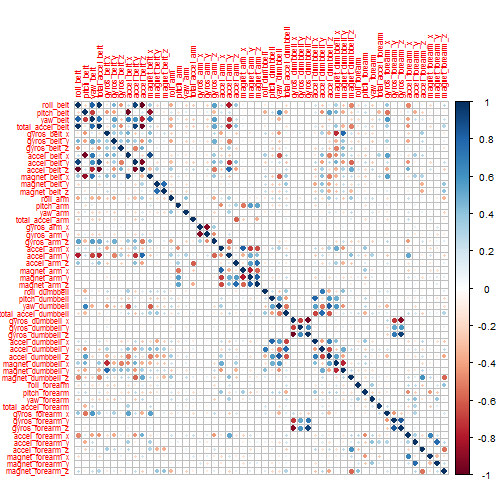

```r
corrM <- cor(training3[, -length(names(training3))])
corrplot(corrM, method = "circle", tl.cex = 0.7)
```

```r
rmcorr <- findCorrelation(corrM, cutoff = .90, verbose = TRUE)
training4 <- training3[,-rmcorr]
testing4 <- testing3[,-rmcorr]
dim(training4); dim(testing4)
```

After removing highly correlated variables both datasets contain each 46 columns/variables.

## Partitioning training set for Cross Validation

```r
set.seed(23232) # reproducibility
partition <- createDataPartition(y = training4$classe, p = 0.7, list = FALSE)
training.final = training4[partition, ]
validation = training4[-partition, ]
dim(training.final); dim(validation)
```

```
## [1] 13737    46
```

```
## [1] 5885   46
```

## Choosing a model

### Predicting with DECISION TREE

First we try DESISION TREE.

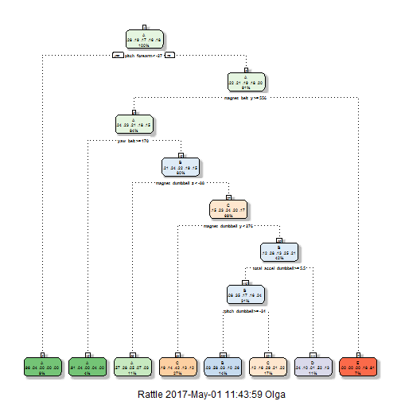

```r
set.seed(23232)
modFitTREE <- train(classe ~ .,method="rpart",data=training.final)
fancyRpartPlot(modFitTREE$finalModel)
```

```r
predTREE <- predict(modFitTREE,newdata=validation)
cfTREE <- confusionMatrix(predTREE,validation$classe)
```

```r
cfTREE$table
```

```
##           Reference
## Prediction    A    B    C    D    E
##          A 1068  210   26   59   18
##          B   25  491   18   94  202
##          C  421  373  977  416  436
##          D  160   65    4  311   72
##          E    0    0    1   84  354
```

```r
cfTREE$overall[1]
```

```
##  Accuracy
## 0.5439252
```

The results with DECISION TREE are very poor. We can exclude this model already on this stage.

### Predicting with GBM

```r
set.seed(23232)
modelFitGBM <- train(classe ~.,data=validation, method="gbm")
predGBM <- predict(modelFitGBM,newdata=validation)
cfGBM <- confusionMatrix(predGBM,validation$classe)
```

```r
cfGBM$table
```

```
##           Reference
## Prediction    A    B    C    D    E
##          A 1662   22    0    1    1
##          B    6 1102   20    1    3
##          C    4   12  997   20    7
##          D    2    0    6  941   10
##          E    0    3    3    1 1061
```

```r
cfGBM$overall[1]
```

```
##  Accuracy
## 0.9792693
```

We have got very good results. But let's try one more model.

### Predicting with RANDOM FOREST

And now we try Random Forest algorithm. It selects automatically important variables and is robust to correlated covariates and outliers in general.

```r
set.seed(23232)
modelFitRF <- train(classe ~.,data=validation, method="rf")

predRF <- predict(modelFitRF,newdata=validation)

cfRF <- confusionMatrix(predRF,validation$classe)
```

```r
cfRF$table
```

```
##           Reference
## Prediction    A    B    C    D    E
##          A 1674    0    0    0    0
##          B    0 1139    0    0    0
##          C    0    0 1026    0    0
##          D    0    0    0  964    0
##          E    0    0    0    0 1082
```

```r
cfRF$overall[1]
```

```
## Accuracy
##        1
```

### Out of Sample Error

```r
control <- trainControl(method="repeatedcv", number=10, repeats=3)
set.seed(23232)
modelRF <- train(classe ~ ., data=training.final, method="rf", trControl=control)
M <- confusionMatrix(predict(modelRF, newdata=validation), validation$classe)
ose <- 1 - M$overall[1]
names(ose)<- "Out of Sample Error"
ose
```

```
## Out of Sample Error
##          0.00815633
```

## Final predictions / RESULTS

```r
predRFtest <- predict(modelFitRF,newdata=testing4)
predRFtest
```

```
##  [1] B A B A A E D D A A B C B A E E A B B B
## Levels: A B C D E
```